# Evaluación Análisis Multivariante

Author

Miguel Cabestrero Martín

```r
library(data.table)
library(dplyr)
library(tidyr)
library(ggplot2)
library(corrplot)
library(skimr)
library(tibble)
library(gt)
library(broom)
library(MASS)
library(mgcv)
library(car)
library(agricolae)
```

```r
# Carga de datos

df <- fread('gym_members_exercise_tracking.csv')

# Por problemas de compatibilidad con Positron, se usa la librería gt en lugar de formattable

df %>%
  skim() %>%
  gt()
```

| skim_type | skim_variable | n_missing | complete_rate | character.min | character.max | character.empty | character.n_unique | character.whitespace | numeric.mean | numeric.sd | numeric.p0 | numeric.p25 | numeric.p50 | numeric.p75 | numeric.p100 | numeric.hist |
| --- | --- | --- | --- | --- | --- | --- | --- | --- | --- | --- | --- | --- | --- | --- | --- | --- |
| character | Gender | 0 | 1 | 4 | 6 | 0 | 2 | 0 | NA | NA | NA | NA | NA | NA | NA | NA |
| character | Workout_Type | 0 | 1 | 4 | 8 | 0 | 4 | 0 | NA | NA | NA | NA | NA | NA | NA | NA |
| numeric | Age | 0 | 1 | NA | NA | NA | NA | NA | 38.683453 | 12.1809279 | 18.00 | 28.00 | 40.00 | 49.00 | 59.00 | ▇▆▇▇▇ |
| numeric | Weight_kg | 0 | 1 | NA | NA | NA | NA | NA | 73.854676 | 21.2075005 | 40.00 | 58.10 | 70.00 | 86.00 | 129.90 | ▅▇▅▂▂ |
| numeric | Height_m | 0 | 1 | NA | NA | NA | NA | NA | 1.722580 | 0.1277199 | 1.50 | 1.62 | 1.71 | 1.80 | 2.00 | ▅▇▇▃▃ |
| numeric | Max_BPM | 0 | 1 | NA | NA | NA | NA | NA | 179.883864 | 11.5256860 | 160.00 | 170.00 | 180.00 | 190.00 | 199.00 | ▇▇▇▇▇ |
| numeric | Avg_BPM | 0 | 1 | NA | NA | NA | NA | NA | 143.766701 | 14.3451014 | 120.00 | 131.00 | 143.00 | 156.00 | 169.00 | ▇▇▆▆▆ |
| numeric | Resting_BPM | 0 | 1 | NA | NA | NA | NA | NA | 62.223022 | 7.3270599 | 50.00 | 56.00 | 62.00 | 68.00 | 74.00 | ▇▆▇▇▇ |
| numeric | Session_Duration_hours | 0 | 1 | NA | NA | NA | NA | NA | 1.256423 | 0.3430335 | 0.50 | 1.04 | 1.26 | 1.46 | 2.00 | ▂▅▇▃▂ |
| numeric | Calories_Burned | 0 | 1 | NA | NA | NA | NA | NA | 905.422405 | 272.6415165 | 303.00 | 720.00 | 893.00 | 1076.00 | 1783.00 | ▃▇▇▂▁ |
| numeric | Fat_Percentage | 0 | 1 | NA | NA | NA | NA | NA | 24.976773 | 6.2594188 | 10.00 | 21.30 | 26.20 | 29.30 | 35.00 | ▂▂▅▇▅ |
| numeric | Water_Intake_liters | 0 | 1 | NA | NA | NA | NA | NA | 2.626619 | 0.6001719 | 1.50 | 2.20 | 2.60 | 3.10 | 3.70 | ▃▆▇▃▆ |
| numeric | Workout_Frequency_days_week | 0 | 1 | NA | NA | NA | NA | NA | 3.321686 | 0.9130470 | 2.00 | 3.00 | 3.00 | 4.00 | 5.00 | ▅▇▁▆▂ |
| numeric | Experience_Level | 0 | 1 | NA | NA | NA | NA | NA | 1.809866 | 0.7396927 | 1.00 | 1.00 | 2.00 | 2.00 | 3.00 | ▇▁▇▁▃ |
| numeric | BMI | 0 | 1 | NA | NA | NA | NA | NA | 24.912127 | 6.6608794 | 12.32 | 20.11 | 24.16 | 28.56 | 49.84 | ▅▇▅▁▁ |

El dataset no presenta valores nulos, por lo que no es necesario realizar ningún tipo de imputación.

Excepto 2 variables, `Gender` y `Workout_Type` que son carácteres, el resto de variables son de tipo numérico. Se realiza una visualización más, en este caso de las primeras 5 líneas del dataset para tener mejor visión de su composición.

```r
head(df, 5)
```

```
     Age Gender Weight_kg Height_m Max_BPM Avg_BPM Resting_BPM
   <int> <char>     <num>    <num>   <int>   <int>       <int>
1:    56   Male      88.3     1.71     180     157          60
2:    46 Female      74.9     1.53     179     151          66
3:    32 Female      68.1     1.66     167     122          54
4:    25   Male      53.2     1.70     190     164          56
5:    38   Male      46.1     1.79     188     158          68
   Session_Duration_hours Calories_Burned Workout_Type Fat_Percentage
                    <num>           <num>       <char>          <num>
1:                   1.69            1313         Yoga           12.6
2:                   1.30             883         HIIT           33.9
3:                   1.11             677       Cardio           33.4
4:                   0.59             532     Strength           28.8
5:                   0.64             556     Strength           29.2
   Water_Intake_liters Workout_Frequency_days_week Experience_Level   BMI
                 <num>                       <int>            <int> <num>
1:                 3.5                           4                3 30.20
2:                 2.1                           4                2 32.00
3:                 2.3                           4                2 24.71
4:                 2.1                           3                1 18.41
5:                 2.8                           3                1 14.39
```

# 1 Regresión Lineal Múltiple

El objetivo es analizar los factores que influyen en las calorías quemadas durante una sesión de entrenamiento.

## 1.1 Planteamiento modelo regresión lineal múltiple

Se plantea un modelo de regresión lineal múltiple donde `Calories_Burned` es la variable dependiente y `Session_Duration_hours`, `Avg_BPM` y `Fat_Percentage` son las variables explicativas.

```r
data_lm <- df %>%
  dplyr::select(Calories_Burned, Session_Duration_hours, Avg_BPM, Fat_Percentage, Gender)

mod1 <- lm(Calories_Burned ~ Session_Duration_hours + Avg_BPM + Fat_Percentage, data = data_lm)
summary(mod1)
```

```
Call:
lm(formula = Calories_Burned ~ Session_Duration_hours + Avg_BPM +
    Fat_Percentage, data = data_lm)

Residuals:
     Min       1Q   Median       3Q      Max
-195.172  -48.010   -0.877   44.438  210.928

Coefficients:
                        Estimate Std. Error t value Pr(>|t|)
(Intercept)            -708.4952    28.4556  -24.90   <2e-16 ***
Session_Duration_hours  668.6425     7.8228   85.47   <2e-16 ***
Avg_BPM                   6.1847     0.1522   40.64   <2e-16 ***
Fat_Percentage           -4.6179     0.4287  -10.77   <2e-16 ***
---
Signif. codes:  0 '***' 0.001 '**' 0.01 '*' 0.05 '.' 0.1 ' ' 1

Residual standard error: 68.06 on 969 degrees of freedom
Multiple R-squared:  0.9379,    Adjusted R-squared:  0.9377
F-statistic:  4877 on 3 and 969 DF,  p-value: < 2.2e-16
```

## 1.2 Incorporación de variable cualitativa Gender

La variable `Gender` es categórica, por lo que para añadirla al modelo es necesario convertirla en una variable dummy (0 o 1). Para realizar esta transformación utilizamos el método `as.factor`, creando una categoría de referencia que recibe el valor 0 y que se asigna a la primera cateogría por orden alfabético. La otra categoría es la de contraste, y es la que aparece explícitamente en el modelo.

```r
df$Gender <- as.factor(df$Gender)

mod1 <- lm(Calories_Burned ~ Session_Duration_hours + Avg_BPM + Fat_Percentage + Gender, data = data_lm)
summary(mod1)
```

```
Call:
lm(formula = Calories_Burned ~ Session_Duration_hours + Avg_BPM +
    Fat_Percentage + Gender, data = data_lm)

Residuals:
     Min       1Q   Median       3Q      Max
-156.677  -51.454    6.531   43.620  201.107

Coefficients:
                        Estimate Std. Error t value Pr(>|t|)
(Intercept)            -911.8112    26.1903  -34.81   <2e-16 ***
Session_Duration_hours  714.9650     7.0223  101.81   <2e-16 ***
Avg_BPM                   6.1521     0.1287   47.80   <2e-16 ***
Fat_Percentage           -0.3960     0.4213   -0.94    0.347
GenderMale               84.4708     4.2944   19.67   <2e-16 ***
---
Signif. codes:  0 '***' 0.001 '**' 0.01 '*' 0.05 '.' 0.1 ' ' 1

Residual standard error: 57.55 on 968 degrees of freedom
Multiple R-squared:  0.9556,    Adjusted R-squared:  0.9554
F-statistic:  5211 on 4 and 968 DF,  p-value: < 2.2e-16
```

## 1.3 Interpretación de los coeficientes

Indicar que aunque se hable de calorías quemadas en la variable dependiente, en realidad se hace referencia a kilocalorías que equivalen a 1,000 calorías.

El modelo muestra la relación de `Calories_Burned` con:

- `Intercept`: Es el valor esperado de calorías quemadas cuando los coeficientes númericos tienen valor 0 y el género es femenino. Su valor estimado es -911.8112, que no tienen una interpretación física directa, actuando principalmente como una constante de ajuste para el modelo.
- `Session_Duration_hours`: Es la variable que más influye en la quema de calorías, e indica que por cada hora de entrenamiento, se queman unas 714.96 kcal.
- `Avg_BPM`: Representa las pulsaciones media durante la sesión de entrenamiento, y muestra que por cada pulsación adicional se queman 6.15 kcal más.
- `Fat_Percentage`: Por cada 1% de grasa adicional que tenga la persona realizando ejercicio, su quema de kcal se reduce en 0.39.
- `GenderMale`: Corresponde a la categoría de contraste de la variable dummy `Gender`, y puede tomar valores 0 o 1 lo que corresponde a mujer u hombre respectivamente. Indica que un hombre realizando exactamente el mismo ejercicio que una mujer quema en promedio 84.47 kcal más.

Atendiendo al P-valor, todos los coeficientes son altamente significativos excepto `Fat_Percentage` con un valor de 0,347 superior al 0.05.

Respecto a la bondad del ajuste, el R cuadrado ajustado muestra que el modelo explica el 95.54% de la varianza de las calorías quemadas, lo que supone un ajuste excelente, aunque podría ser conveniente realizar alguna comprobación ya que es un valor muy alto. También es un valor prácticamente similar al R cuadrado (0.9556), lo que inidica que las varibles seleccionadas son relevantes. Esto está en línea con el estadístico F con un valor de 5211 y el p-valor de 2.2e-16.

Una vez analizado el modelo con `Gender`como variable explicativa se hace una observación respecto a las diferencias con el modelo anterior donde no se incluía.

En la comparativa se puede apreciar como `Fat_Percentage` pasa de un valor de -4.6179 a -0.3960, reduciéndose drásticamente su relevancia para explicar las calorías quemadas, así como su significancia, que antes era <2e-16. Esto se debe seguramente a que antes de la inclusión del género, las diferencias físicas entre hombres y mujeres respecto al promedio de grasa corporal, estaban intentado ser explicadas a través del porcentaje de grasa únicamente.

También ha habido una mejora en el ajuste del modelo pasando de un R cuadrado ajustado de 0.9377 a 0.9554 y un ajuste del intercepto. Por otro lado, la duración del entrenamiento también aumento su importancia en las calorías consumidas.

## 1.4 Intervalos de confianza

Validaremos la robustez del parámetro `Avg_BPM` calculando el intervalo de confianza para un α = 0.05.

```r
int_confianza_avg_BPM <- confint(mod1, "Avg_BPM", level = 0.95)
# Extraer el límite inferior
limite_inferior <- int_confianza_avg_BPM[1, 1]
# Extraer el límite superior
limite_superior <- int_confianza_avg_BPM[1, 2]
# Extraer el coeficiente
avg_bpm_coef <- coef(mod1)["Avg_BPM"]

# Se crea un dataframe para mostrar los resultados
tabla_bpm <- data.frame(
  coeficiente = avg_bpm_coef,
  lower = limite_inferior,
  upper = limite_superior
)

print(tabla_bpm)
```

```
        coeficiente    lower    upper
Avg_BPM    6.152072 5.899483 6.404662
```

El intervalo de confianza al 95% está entre 5.89 y 6.40. Al no encontrarse el 0 en ese rango, podemos decir que a ese nivel de confianza la frecuencia cardíaca es un predictor estadísticamente significativo de las calorías quemadas. Con un 95% de confianza, se puede afirmar que por cada latido por minuto adicional, el incremento promedio en las calorías quemadas se sitúa entre 5.89 y 6.40. Por último, este intervalo es estrecho, lo que indica que se trata de una estimación robusta.

## 1.5 Predicción puntual

Se realiza una predicción puntual de una serie de individuos utilizando el `mod1` creado en apartados anteriores.

```r
datos_predecir <- data.frame(
    Session_Duration_hours = c(1.25, 1.30, 1.75, 0.45, 2.00),
    Avg_BPM = c(125,  150,  133,  158,  139),
    Fat_Percentage = c(12,   21,   28,   30,   19),
    Gender = factor(c("Male", "Female", "Male", "Male", "Female"),
    # Para asegurar que los niveles del dataset original se mantienen (female = 0, male = 1)
    # se utiliza levels
    levels = levels(df$Gender)))

pred_dato <- data.frame(predict(mod1, datos_predecir, interval="prediction", type="response"))

# se unen las dos tablas y se renombran las columnas de las predicciones
prediccion <- bind_cols(datos_predecir, pred_dato) %>% rename(PRED = fit, PRED_LOWER = lwr, PRED_UPPER = upr) %>%
  mutate(AMPLITUD = PRED_UPPER - PRED_LOWER)
remove(pred_dato)  # se eliminan los datos de la memoria

prediccion %>%
  gt() %>%
  fmt_number(columns = where(is.numeric), decimals = 2)
```

| Session_Duration_hours | Avg_BPM | Fat_Percentage | Gender | PRED | PRED_LOWER | PRED_UPPER | AMPLITUD |
| --- | --- | --- | --- | --- | --- | --- | --- |
| 1.25 | 125.00 | 12.00 | Male | 830.62 | 717.13 | 944.11 | 226.98 |
| 1.30 | 150.00 | 21.00 | Female | 932.14 | 818.94 | 1,045.33 | 226.39 |
| 1.75 | 133.00 | 28.00 | Male | 1,230.99 | 1,117.42 | 1,344.55 | 227.13 |
| 0.45 | 158.00 | 30.00 | Male | 454.54 | 341.11 | 567.98 | 226.87 |
| 2.00 | 139.00 | 19.00 | Female | 1,365.73 | 1,252.39 | 1,479.08 | 226.69 |

La amplitud del intervalo es muy constante entre todas las predicciones, con un valor aproximado de 226. Esto es un indicador de homocedasticidad, lo que suigiere un modelo uniforme para diferentes registros.

# 2 Regresión robusta y modelos aditivos

## 2.1 Modelos de regresión robusta

Se realiza un modelo de regresión robusta basado en el modelo del apartado anterior. El objetivo es mitigar el efecto de los posibles valores atípicos que, por su distancia respecto a la recta y su elevado leverage, podrían estar sesgando los coeficientes del modelo original. De este modo, obtenemos una estimación más fiable que no se ve arrastrada por observaciones extremas.

Para realizar el ajuste se utilizarán 2 estimadores:

- Huber que trata de forma normal a los datos con residuos pequeños, pero aplica un castigo lineal moderado a los valores atípicos para que no desplacen la recta de regresión.
- Bisquare es más estricto ya que utiliza una función de peso ponderada, llegando a ignorar por completo a los valores extremadamente alejados para asegurar que la predicción solo se base en el patrón principal de los datos.

```r
# Recordar primero el error estándar del modelo original

summary(mod1)
```

```
Call:
lm(formula = Calories_Burned ~ Session_Duration_hours + Avg_BPM +
    Fat_Percentage + Gender, data = data_lm)

Residuals:
     Min       1Q   Median       3Q      Max
-156.677  -51.454    6.531   43.620  201.107

Coefficients:
                        Estimate Std. Error t value Pr(>|t|)
(Intercept)            -911.8112    26.1903  -34.81   <2e-16 ***
Session_Duration_hours  714.9650     7.0223  101.81   <2e-16 ***
Avg_BPM                   6.1521     0.1287   47.80   <2e-16 ***
Fat_Percentage           -0.3960     0.4213   -0.94    0.347
GenderMale               84.4708     4.2944   19.67   <2e-16 ***
---
Signif. codes:  0 '***' 0.001 '**' 0.01 '*' 0.05 '.' 0.1 ' ' 1

Residual standard error: 57.55 on 968 degrees of freedom
Multiple R-squared:  0.9556,    Adjusted R-squared:  0.9554
F-statistic:  5211 on 4 and 968 DF,  p-value: < 2.2e-16
```

El error estándar del modelo original es 57.55

```r
# Estimador Huber
mod_huber <- rlm(Calories_Burned ~  Session_Duration_hours + Avg_BPM + Fat_Percentage + Gender, data = data_lm)
summary(mod_huber)
```

```
Call: rlm(formula = Calories_Burned ~ Session_Duration_hours + Avg_BPM +
    Fat_Percentage + Gender, data = data_lm)
Residuals:
     Min       1Q   Median       3Q      Max
-159.240  -50.067    6.955   43.039  208.698

Coefficients:
                       Value     Std. Error t value
(Intercept)            -892.8645   26.1572   -34.1345
Session_Duration_hours  714.1014    7.0134   101.8200
Avg_BPM                   6.0060    0.1286    46.7212
Fat_Percentage           -0.2506    0.4208    -0.5956
GenderMale               82.5911    4.2890    19.2566

Residual standard error: 69.93 on 968 degrees of freedom
```

El error estándar para el modelo robusto de Huber es de 69.93

```r
# Estimador bisquare
mod_bisquare <- rlm(Calories_Burned ~  Session_Duration_hours + Avg_BPM + Fat_Percentage + Gender, data = data_lm, psi = psi.bisquare)
summary(mod_bisquare)
```

```
Call: rlm(formula = Calories_Burned ~ Session_Duration_hours + Avg_BPM +
    Fat_Percentage + Gender, data = data_lm, psi = psi.bisquare)
Residuals:
     Min       1Q   Median       3Q      Max
-160.031  -49.900    6.452   43.049  209.864

Coefficients:
                       Value     Std. Error t value
(Intercept)            -886.0057   27.2907   -32.4655
Session_Duration_hours  713.4412    7.3173    97.5009
Avg_BPM                   5.9705    0.1341    44.5159
Fat_Percentage           -0.2781    0.4390    -0.6336
GenderMale               82.1005    4.4748    18.3472

Residual standard error: 69.56 on 968 degrees of freedom
```

El error estándar para el estimador bisquare es 69.56.

Las observaciones principales del análisis descriptivo son:

- Los errores estándar de los modelos robustos son mayores que el modelo original (aproximadamente 69 frente a 57). Esto significa que el modelo original es sólido, no viéndose influenciado por valores extremos.
- Los coeficientes entre los modelos se mantienen constantes con variaciones muy pequeñas, siendo el porcentaje de grasa poco significativo en todos los modelos.

Se realiza a continuación un análisis gráfico de los 3 modelos, comparando los valores observados frente a los predichos.

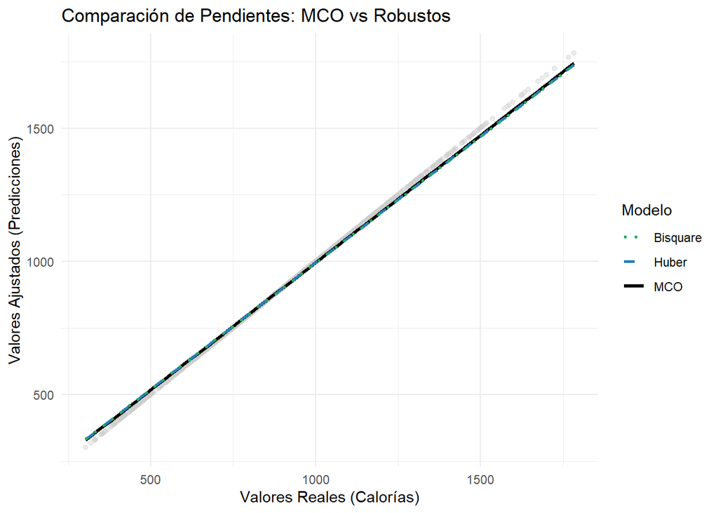

```r
# Preparación de datos en dataframe
df_juntos <- data.frame(
  real     = data_lm$Calories_Burned,
  mco      = mod1$fitted.values,
  huber    = mod_huber$fitted.values,
  bisquare = mod_bisquare$fitted.values
)

ggplot(df_juntos, aes(x = real)) +
  # Puntos reales
  geom_point(aes(y = real), color = "gray80", alpha = 0.4, size = 1.5) +

  # Línea de MCO
  geom_smooth(aes(y = mco, color = "MCO"),
              method = "lm", formula = y ~ x, se = FALSE, linetype = "solid", linewidth = 1.2) +

  # Línea de Huber
  geom_smooth(aes(y = huber, color = "Huber"),
              method = "lm", formula = y ~ x, se = FALSE, linetype = "dashed", linewidth = 1) +

  # Línea de Bisquare
  geom_smooth(aes(y = bisquare, color = "Bisquare"),
              method = "lm", formula = y ~ x, se = FALSE, linetype = "dotted", linewidth = 1) +

  # Colores y Leyenda
  scale_color_manual(values = c("MCO" = "black",
                                "Huber" = "#2980B9",
                                "Bisquare" = "#27AE60")) +

  # Etiquetas
  labs(title = "Comparación de Pendientes: MCO vs Robustos",
       x = "Valores Reales (Calorías)",
       y = "Valores Ajustados (Predicciones)",
       color = "Modelo") +

  theme_minimal() +
  theme(legend.position = "right")
```

En el análisis gráfico se puede ver que los tres modelos representan una línea similar, estando prácticamente superpuestos. La pendiente que dibujan es muy similar a la diagonal de 45º que representa los valores reales, por lo que los 3 modelos hacen un buen trabajo predictivo y no se ven apenas desplazados por la presencia de valores extremos.

Tras realizar los 2 análisis, el cuantitativo y el gráfico, ya que este último no muestra diferencias significativas entre los modelos y lo errores son menores en el modelo original, **se opta por el modelo de regresión original (MCO), que es el que presenta un error estándar menor**.

## 2.2 Modelo con splines

Se propone un modelo con splines que predice las calorías quemadas en base a las variables utilizadas en los apartados anteriores. Para identificar que variables son susceptibles de presentar curvatura en su relación con la variable dependiente se calcula la matriz de correlación.

```r
# Solo para variables numéricas
vars_num <- data_lm[, c('Calories_Burned', 'Session_Duration_hours', 'Avg_BPM', 'Fat_Percentage')]
cor_matrix <- cor(vars_num)
print(cor_matrix)
```

```
                       Calories_Burned Session_Duration_hours      Avg_BPM
Calories_Burned              1.0000000             0.90814038  0.339658667
Session_Duration_hours       0.9081404             1.00000000  0.016014438
Avg_BPM                      0.3396587             0.01601444  1.000000000
Fat_Percentage              -0.5976152            -0.58151977 -0.007301655
                       Fat_Percentage
Calories_Burned          -0.597615248
Session_Duration_hours   -0.581519771
Avg_BPM                  -0.007301655
Fat_Percentage            1.000000000
```

Los resultados muestran que la duración de la sesión tiene un coeficiente de correlación de casi 0.91, lo que indica que se trata de una relación altamente lineal. Las pulsaciones medias y el índice de grasa, presentan una correlación menor, de 0.33 y -0.597 respectivamente. Por lo tanto, se explorará su comportamiento tras aplicar la función de suavizado.

Para ello, se utiliza la función `gam` al tratarse de varias variables. Esta función realiza una regresión por splines utilizando una base de splines cúbicos penalizados.

```r
# Session_Duration_hours se deja lineal según el análisis de correlación
mod_spline_refinado <- gam(Calories_Burned ~ Session_Duration_hours +
                           s(Avg_BPM) +
                           s(Fat_Percentage) +
                           Gender,
                           data = data_lm)
```

```r
# Se comparan los valores de R-cuadrado ajustado
r2_lineal <- summary(mod1)$adj.r.squared
r2_gam <- summary(mod_spline_refinado)$r.sq

cat('R-cuadrado Ajustado Modelo Lineal:', r2_lineal, '\n')
```

```
R-cuadrado Ajustado Modelo Lineal: 0.9554394
```

```r
cat('R-cuadrado Ajustado Modelo GAM:', r2_gam, '\n')
```

```
R-cuadrado Ajustado Modelo GAM: 0.9570578
```

```r
# Se comparan los modelos estadísticamente
anova(mod1, mod_spline_refinado, test = 'F')
```

```
Analysis of Variance Table

Model 1: Calories_Burned ~ Session_Duration_hours + Avg_BPM + Fat_Percentage +
    Gender
Model 2: Calories_Burned ~ Session_Duration_hours + s(Avg_BPM) + s(Fat_Percentage) +
    Gender
  Res.Df     RSS     Df Sum of Sq      F   Pr(>F)
1 968.00 3206349
2 964.03 3077236 3.9659    129113 10.199 4.86e-08 ***
---
Signif. codes:  0 '***' 0.001 '**' 0.01 '*' 0.05 '.' 0.1 ' ' 1
```

La variabilidad explicada por el modelo original y el nuevo modelo GAM apenas ha cambiado con un aumento de 0.955 a 0.957. Sin embargo, el P-valor indica que esta diferencia, a pesar de ser pequeña, es significativa, por lo que se se confirma que la flexibilidad aportada por los splines en `Avg_BPM` y `Fat_Percentage` mejora el modelo de forma significativa. **Se opta por tanto por el modelo GAM**.

# 3 Modelo Lineal Generalizado

Se define una nueva variable binaria `High_Intensity`, que toma valor 1 si `Avg_BPM` es superior a 140 y 0 en caso contrario.

```r
df$High_Intensity <- ifelse(df$Avg_BPM > 140, 1, 0)

df$High_Intensity <- as.factor(df$High_Intensity)
```

Para garantizar el correcto funcionamiento del modelo, también se transforman a factor las variables del tipo de ejercicio y el nivel de experiencia, ya que la primera es texto, mientras que la segunda es entero.

```r
df$Workout_Type <- as.factor(df$Workout_Type)
df$Experience_Level <- as.factor(df$Experience_Level)
```

Antes de formular el modelo se discretizan las variables numéricas como se pide en el enunciado.

```r
min_age <- min(df$Age)
print(min_age)
```

```
[1] 18
```

```r
max_age <- max(df$Age)
print(max_age)
```

```
[1] 59
```

```r
max_weight <- max(df$Weight_kg)
print(max_weight)
```

```
[1] 129.9
```

```r
# Discretización de la Edad
df$Age_Cat <- cut(as.numeric(df$Age),
                       breaks = c(18, 30, 45, 60),
                       labels = c("Joven", "Adulto_Joven", "Adulto"),
                       include.lowest = TRUE)

# Discretización del Peso
df$Weight_Cat <- cut(as.numeric(df$Weight_kg),
                          breaks = c(0, 65, 85, 250),
                          labels = c("Ligero", "Medio", "Pesado"),
                          include.lowest = TRUE)
```

Se formula un modelo lineal generalizado binomial para explicar `High_Intensity` en función de `Age`, `Gender`, `Weight_kg`, `Experiencie_Level`, `Workout_Type`. Pero antes se realiza una comprobación de las variables que se usarán.

```r
df_MLG <- df %>%
  dplyr::select(High_Intensity, Age_Cat, Weight_Cat, Gender, Experience_Level, Workout_Type)

skim(df_MLG)
```

Data summary

| Name | df_MLG |
| --- | --- |
| Number of rows | 973 |
| Number of columns | 6 |
| Key | NULL |
| _______________________ |  |
| Column type frequency: |  |
| factor | 6 |
| ________________________ |  |
| Group variables | None |

**Variable type: factor**

| skim_variable | n_missing | complete_rate | ordered | n_unique | top_counts |
| --- | --- | --- | --- | --- | --- |
| High_Intensity | 0 | 1 | FALSE | 2 | 1: 532, 0: 441 |
| Age_Cat | 0 | 1 | FALSE | 3 | Adu: 348, Adu: 330, Jov: 295 |
| Weight_Cat | 0 | 1 | FALSE | 3 | Lig: 398, Med: 316, Pes: 259 |
| Gender | 0 | 1 | FALSE | 2 | Mal: 511, Fem: 462 |
| Experience_Level | 0 | 1 | FALSE | 3 | 2: 406, 1: 376, 3: 191 |
| Workout_Type | 0 | 1 | FALSE | 4 | Str: 258, Car: 255, Yog: 239, HII: 221 |

El **modelo elegido es Logit**, debido a que permite una mejor interpretabilidad mediante Odds Ratios. A diferencia del modelo Probit, que se basa en la distribución normal y ofrece coeficientes difíciles de interpretar, el modelo Logit permite transformar los coeficientes en Odds Ratios (razones de probabilidad).

```r
mod_logit <- glm(High_Intensity ~ Age_Cat + Gender + Weight_Cat + Experience_Level + Workout_Type,
                    data = df_MLG,
                    family = binomial(link = "logit"))

# odds ratio
summary(mod_logit)
```

```
Call:
glm(formula = High_Intensity ~ Age_Cat + Gender + Weight_Cat +
    Experience_Level + Workout_Type, family = binomial(link = "logit"),
    data = df_MLG)

Coefficients:
                       Estimate Std. Error z value Pr(>|z|)
(Intercept)           0.1830912  0.1984395   0.923    0.356
Age_CatAdulto_Joven   0.1244496  0.1596512   0.780    0.436
Age_CatAdulto         0.1759311  0.1616842   1.088    0.277
GenderMale           -0.1091909  0.1623151  -0.673    0.501
Weight_CatMedio      -0.0674613  0.1570154  -0.430    0.667
Weight_CatPesado     -0.0004581  0.2018931  -0.002    0.998
Experience_Level2     0.0935091  0.1442755   0.648    0.517
Experience_Level3     0.0122412  0.1797058   0.068    0.946
Workout_TypeHIIT     -0.1313051  0.1852372  -0.709    0.478
Workout_TypeStrength -0.0048838  0.1789220  -0.027    0.978
Workout_TypeYoga     -0.1219579  0.1817112  -0.671    0.502

(Dispersion parameter for binomial family taken to be 1)

    Null deviance: 1340.3  on 972  degrees of freedom
Residual deviance: 1336.9  on 962  degrees of freedom
AIC: 1358.9

Number of Fisher Scoring iterations: 4
```

Un primer análisis muestra que ninguna de las variables es significativa atendiendo al P-valor.

## 3.1 Interpretación de los coeficientes del modelo

El intercepto del modelo representa a una mujer joven (18-30 años), con un peso ligero (0-65 kg), con nivel principiante y que entrena cardio. Para interpretar el resto de coeficientes, es más intuitivo utilizar los odds ratios (OR). Su interpretación es la siguiente:

- OR = 1 indica que no hay efecto.
- OR > 1 indica que el efecto es positivo, aumentando la probabilidad de que la variable `High_Intensity` sea 1, es decir, que sea intensa.
- OR < 1 indica un efecto negativo, es decir, la probabilidad de una alta intensidad será menor.

```r
odds_ratios <- exp(coef(mod_logit))

tabla_or <- data.frame(
  Variable = names(odds_ratios),
  Odds_Ratio = round(odds_ratios, 3),
  row.names = NULL
)
print(tabla_or)
```

```
               Variable Odds_Ratio
1           (Intercept)      1.201
2   Age_CatAdulto_Joven      1.133
3         Age_CatAdulto      1.192
4            GenderMale      0.897
5       Weight_CatMedio      0.935
6      Weight_CatPesado      1.000
7     Experience_Level2      1.098
8     Experience_Level3      1.012
9      Workout_TypeHIIT      0.877
10 Workout_TypeStrength      0.995
11     Workout_TypeYoga      0.885
```

Al observar la tabla, se pueden extraer tendencias sobre quién tiene más o menos probabilidades de superar los 140 BPM en comparación con el perfil base (Mujer, Joven, Peso Ligero, Principiante y Cardio):

- Edad: A mayor edad, mayor es la probabilidad de realizar ejercicio de alta intensidad.
- Género: Los hombres presentan una probabilidad ligeramente inferior a la de las mujeres para alcanzar este umbral de 140 BPM.
- Peso: el peso no muestra una relación lineal. Mientras que las personas pesadas se comportan igual que las ligeras (OR 1.00), el grupo de peso medio presenta la menor probabilidad de alta intensidad.
- Experiencia: La experiencia apenas varia la probabilidad, aunque las personas con experiencia media son las más probables de realizar un ejercicio de alta intensidad.
- Tipo de ejercicio: El cardio es el ejercicio que más probabilidades tiene de resultar en un ejercicio de alta intensidad y HIIT el que menos por un pequeño margen.

## 3.2 Evaluación del ajuste del modelo

```r
R2_McFadden <- 1 - (mod_logit$deviance / mod_logit$null.deviance)
print(R2_McFadden)
```

```
[1] 0.002582498
```

```r
# Test de significación global del modelo
p_valor_global <- pchisq(mod_logit$null.deviance - mod_logit$deviance,
                         df = mod_logit$df.null - mod_logit$df.residual,
                         lower.tail = FALSE)
print(p_valor_global)
```

```
[1] 0.9683918
```

Para evaluar el ajuste del modelo se utiliza el pseudo R cuadrado de McFadden. Este arroja 0.00258, muy por debajo de los niveles aceptables [0,2, 0,4] lo que indica que el modelo explica un porcentaje muy bajo de la variabilidad de la intensidad, apenas un 0.3%. Esto guarda coherencia con el ajuste global del modelo mediante un test de razón de verosimilitud, obteniendo un p-valor de 0.968. Dado que este valor es muy superior al umbral de significación (0.05), no existe evidencia estadística de que el modelo con predictores sea superior al modelo nulo.

# 4 Diseño de experimentos (I)

Para ello, se plantea un modelo ANOVA bifactorial con interacción para explicar `Calories_Burned`. Considere `Gender` y `Experience_Level` como factores fijos. Lo primero es seleccionar las variables usadas en el modelo.

```r
df_aov <- df %>%
  dplyr::select(Calories_Burned, Gender, Experience_Level)
```

```r
mod_anova <- aov(Calories_Burned ~ Gender * Experience_Level, data = df_aov)
summary(mod_anova)
```

```
                         Df   Sum Sq  Mean Sq F value  Pr(>F)
Gender                    1  1639714  1639714  47.105 1.2e-11 ***
Experience_Level          2 36746808 18373404 527.824 < 2e-16 ***
Gender:Experience_Level   2   204568   102284   2.938  0.0534 .
Residuals               967 33660970    34810
---
Signif. codes:  0 '***' 0.001 '**' 0.01 '*' 0.05 '.' 0.1 ' ' 1
```

## 4.1 Análisis de hipótesis

Antes de proceder a la interpretación de los resultados del ANOVA, es imperativo validar los tres supuestos fundamentales que garantizan la fiabilidad de las inferencias estadísticas: independencia, normalidad y homocedasticidad. La independencia está relacionado con el diseño de la recogida de datos, por lo que asumiremos que se cumple.

### 4.1.1 Normalidad de los residuos

Para analizar la normalidad de los residuos se utiliza el test de Shapiro.

```r
shapiro.test(residuals(mod_anova))
```

```
    Shapiro-Wilk normality test

data:  residuals(mod_anova)
W = 0.99049, p-value = 6.257e-06
```

El p-valor es muy inferior a 0.05 por lo que se rechaza la hipótesis nula de normalidad de los errores.

### 4.1.2 Homocedasticidad de las varianzas

La homocedasticidad se contrasta mediante el test de Flinger-Killeen por su mayor robusted cuando no hay normalidad ya que se basa en la mediana.

```r
fligner.test(Calories_Burned ~ interaction(Gender, Experience_Level), data = df_aov)
```

```
    Fligner-Killeen test of homogeneity of variances

data:  Calories_Burned by interaction(Gender, Experience_Level)
Fligner-Killeen:med chi-squared = 91.23, df = 5, p-value < 2.2e-16
```

El P-valor es menor que 0.05 por lo que no se cumple homocedasticidad, lo que significa que existen diferencias significativas en las varianzas de los grupos.

Una posible estrategia para conseguir cumplir con la normalidad y homocedasticidad es hacer una trasnformación Box-Cox, pero al no solicitarse en el enunciado, el análisis se continuará con el modelo original.

## 4.2 Comprobación de diferencias significativas entre géneros

El P-valor de la variable género en la tabla ANOVA es 1.2e-11, que al ser mucho menor que 0.05 significa que se rechaza la hipótesis nula de igualdad de medias entre los géneros y que por tanto las calorías consumidas entre hombres y mujeres es significativamente diferente.

## 4.3 Interacción nivel de experiencia, geénero y calorías quemadas

La tabla ANOVA indica que el género y nivel de experiencia son significativos de manera inidividual. Sin emabrgo, la interacción entre ambos es significtiva solo al 10% (p-valor 0.0534).

Para indagar en la interacción entre ambas variables ser realizará un análisis gráfico.

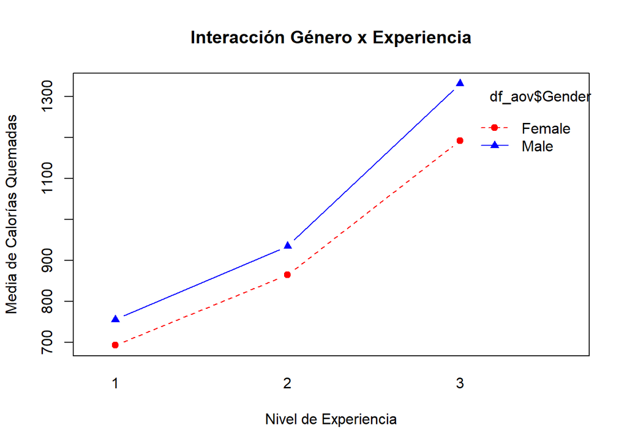

```r
interaction.plot(x.factor = df_aov$Experience_Level,
                 trace.factor = df_aov$Gender,
                 response = df_aov$Calories_Burned,
                 fun = mean,
                 type = "b",
                 col = c("red", "blue"),
                 pch = c(19, 17),
                 fixed = TRUE,
                 main = "Interacción Género x Experiencia",
                 xlab = "Nivel de Experiencia",
                 ylab = "Media de Calorías Quemadas")
```

El resultado parece indicar que las diferencias entre géneros son relativamente estables entre el nivel de 1 y 2 de experiencia, pero estas se acentúan claramente en el nivel de máxima experiencia. En este nivel, los hombres queman más calorías que las muejeres en comparación al resto de niveles.

## 4.4 Comparaciones post-hoc

```r
# Se crea la variable de interacción para que sea un único factor
df_aov$inter_celda <- interaction(df_aov$Gender, df_aov$Experience_Level)

#  Se ajusta el modelo usando ese nuevo factor
# (Importante: scheffe.test necesita que el modelo se base en el factor a contrastar)
mod_auxiliar <- aov(Calories_Burned ~ inter_celda, data = df_aov)

# Se ejecuta el test correctamente
res_scheffe <- agricolae::scheffe.test(mod_auxiliar, 'inter_celda', group = TRUE, console = FALSE)

# Se muestran los resultados
print(res_scheffe$groups)
```

```
         Calories_Burned groups
Male.3         1330.9406      a
Female.3       1191.7222      b
Male.2          935.2958      c
Female.2        865.0829      d
Male.1          756.2132      e
Female.1        693.5363      e
```

El test de Scheffe confirma que casi todas las combinaciones de género y experiencia presentan medias significativamente diferentes entre sí excepto los géneros con nivel de experiencia 1. Por lo que una vez que el nivel de experienica pasa de uno, el género es un factor significativo respecto a la media de calorías consumidas.

# 5 Diseño de experimentos II

El primer paso para cumplir con lo solicitado en el enunciado es categorizar la edad según los intervalos indicados.

```r
# Discretización de la Edad sobreescribiendo la categorización anterior
df$Age_Cat <- cut(as.numeric(df$Age),
                       breaks = c(18, 25, 35, 45, 55, 60),
                       labels = c('18–25', '26–35', '36–45', '46–55', '56-60'),
                       include.lowest = TRUE)
```

## 5.1 Planteamiento del modelo

Una vez discretizada, se plantea un modelo ANOVA. Se quiere conocer la interacción entre el nivel de experiencia, el tipo de entrenamiento y las calorías quemadas. Los grupos de edad se incluyen sumando (sin interacción) ya que se utilizan para eliminar el efecto de la edad en la varianza residual, aumentando la potencia de los contrastes.

```r
df_aov2 <- df %>%
  dplyr::select(Calories_Burned, Experience_Level, Workout_Type, Age_Cat)
```

```r
mod_anova2 <- aov(Calories_Burned ~ Experience_Level * Workout_Type + Age_Cat, data = df_aov2)
summary(mod_anova2)
```

```
                               Df   Sum Sq  Mean Sq F value   Pr(>F)
Experience_Level                2 36801094 18400547 523.117  < 2e-16 ***
Workout_Type                    3   134164    44721   1.271    0.283
Age_Cat                         4  1424485   356121  10.124 4.98e-08 ***
Experience_Level:Workout_Type   6   230016    38336   1.090    0.366
Residuals                     957 33662303    35175
---
Signif. codes:  0 '***' 0.001 '**' 0.01 '*' 0.05 '.' 0.1 ' ' 1
```